# Food Consumption and CO2 Emissions

Brendan Octaviano

23/01/2022

# Introduction

Carbon Dioxide, or more commonly referred to as CO2, is a greenhouse gas resulting from a number of human activities. When overproduced, it contributes to what is known as the greenhouse gas effect - a natural process that warms the Earth’s surface. What generally happens is when the sun radiates heat and energy, it is either reflected back into space, or it penetrates the earth’s atmosphere, trapped by greenhouse gas to help keep Earth warm enough to sustain life. However, due to the overproduction of greenhouse gases like CO2, this contributes to the levels of greenhouse gas, trapping unnecessary heat within our atmosphere.

This is the underlying cause of what is known as climate change, and is resulting in detrimental effects to the Earth’s climate. One contributor to climate change is the effect of food production. According to a report from [Ritchie and Roser (2020)](https://ourworldindata.org/environmental-impacts-of-food), one-quarter of the world’s greenhouse gas emissions come from the production of food. This suggests that turning our attention on both food and food consumption is integral to targeting the underlying issue of climate change.

*Throughout this report, I’ve included the code used in collapsible sections. For more insight into how I developed a particular solution, just click “code”.*

# Our Data

nu3, a German company focusing on supplying supplements and nutritional food products to European countries, have released a [dataset](https://www.nu3.de/blogs/nutrition/food-carbon-footprint-index-2018) exploring food consumption for different food categories, along with their corresponding CO2 emissions, for 130 different countries in 2018. As a result, by utilising the data available, we would like to explore the following questions:

*1. Which countries should we focus on because of their CO2 emissions, both as a whole, as well as for different food categories?*  
*2. Does non-animal product consumption minimise the effects of CO2 emissions from food consumption?*

Fortunately, this data was scraped and cleaned by [Kasia Kulma](https://r-tastic.co.uk/post/from-messy-to-tidy/), so no further cleaning was required.

```r
#Set seed for reproducability
set.seed(1)

#Loading our packages
library(tidyverse)
library(repr)
library(ggrepel)
library(knitr)

#Loading the data
food.consumption <- read_csv('https://raw.githubusercontent.com/rfordatascience/tidytuesday/master/data/2020/2020-02-18/food_consumption.csv')

head(food.consumption) %>%
  kable()
```

| country | food_category | consumption | co2_emmission |
| --- | --- | --- | --- |
| Argentina | Pork | 10.51 | 37.20 |
| Argentina | Poultry | 38.66 | 41.53 |
| Argentina | Beef | 55.48 | 1712.00 |
| Argentina | Lamb & Goat | 1.56 | 54.63 |
| Argentina | Fish | 4.36 | 6.96 |
| Argentina | Eggs | 11.39 | 10.46 |

# Methodology: K-Means Clustering

Through the use of K-Means clustering, we are aiming to group our countries and food categories together so that we can effectively answer the questions we have posed.

K-Means clustering is an unsupervised machine learning technique that aims to partition a datasets observations into K different clusters thorough multiple iterations, in such a way that each observation belongs to only a single group that has similar qualities. Clustering in general takes on an important concept of distance. Distance, in a literal sense, measures how far one thing is from another, however in the world of machine learning, it refers to how similar (or dissimilar) two observations are. The larger the distance between two observations, the less similar they are, and vice versa.

By calculating the Euclidian distance between objects based on defined variables, K-means looks to minimise the “within sum of squares”, while also maximising the “between sum of squares”. In other words, we are looking to cluster our observations in such a way where are minimising the within-cluster dispersion, and maximise the between-cluster dispersion, ensuring that we have clear segments.

Applying K-Means clustering to our data will give us the ability to group our countries that have similar levels of consumption per food group, as well as CO2 emissions, so we can see firstly which countries we should turn our attention to, as well as what food categories in countries we should focus on.

# Evaluating Model

After running our K-Means clustering with a number of different clusters using a for loop, we are able to visibly see which number of clusters is optimal, where optimal is a balance between minimising the “within sum of squares”, while also maximising the “between sum of squares”.

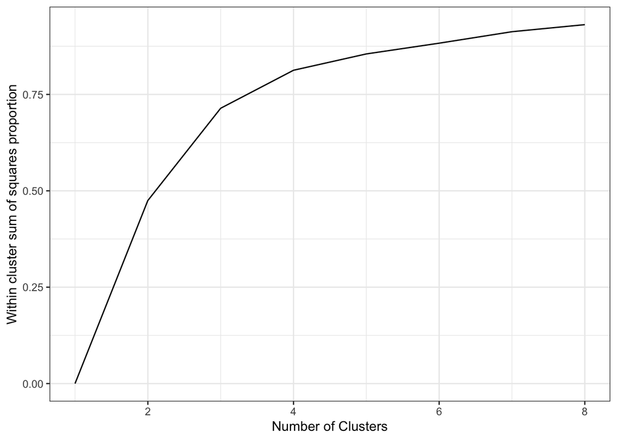

```r
food.consumption.scaled <- food.consumption %>%
  #Selecting only our numerical columns in the data so that we can cluster based on those values
  select(consumption, co2_emmission) %>%
  #Important to scale numerical values. While looking at the metadata, the values are already standardised, however consumption         #tends to be on a much lower scale compared to Co2 emissions
  scale

#In order to choose an optimal number of clusters, we can use a for loop and calculate the total within sum of squares, as well as the between sum of squares / total sum of squares

n <- 8
ss.df <- data.frame(k = numeric(n),
                    ss = numeric(n),
                    tot = numeric(n))

for(i in 1:n){
  km <- kmeans(food.consumption.scaled, centers = i, nstart = 25)
  ss.df$k[i] <- i
  ss.df$ss[i] <- km$betweenss / km$totss
  ss.df$tot[i] <- km$tot.withinss
}

#Plotting these against the corresponding number of clusters wil allow us to decide the optimal number of clusters for our analysis
ss.df %>%
  ggplot(aes(x = k,
             y = ss)) +
  geom_line() +
  labs(x = "Number of Clusters",
       y = "Within cluster sum of squares proportion") +
  theme_bw()
```

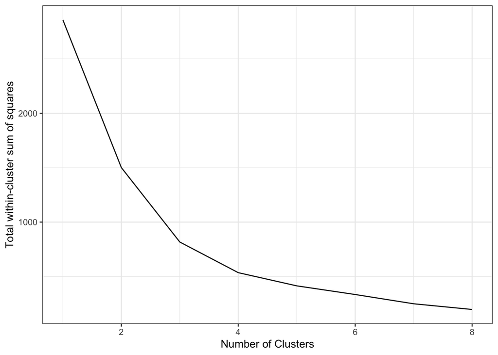

```r
ss.df %>%
  ggplot(aes(x = k,
             y = tot)) +
  geom_line() +
  labs(x = "Number of Clusters",
       y = "Total within-cluster sum of squares") +
  theme_bw()
```

As a general rule of thumb, we can choose the number of clusters where the gradient begins to flatten looking at both plots, which is when we choose 4 clusters. This was the case for both of our K-Means clustering, which will be detailed below.

Furthermore, after assessing both of our K-Means clustering, our *between sum of squares to total sum of squares ratio was both above 0.8, or 80%*. This value tells us how good the clustering that our K-Means has found, giving us a measure of the total variance in our data set that is explained by our clustering, indicating that we have split our data fairly accurately.

The two K-Means clustering we performed was for the purpose of answering our first question:

*Which countries should we focus on because of their CO2 emissions, both as a whole, as well as for different food categories?*